# Анализ телеграм канала Кинопоиска

**Цели анализа:** оценить состояния телеграм канала Кинопоиска, подобрать наилучшие метрики для оценки эффективности канала.

**Задачи:**

1. Вывести метрики эффективности поста
   - Тип публикации
   - Тема
   - Объем текста
   - Отсутствие / наличие эмодзи
   - Отсутствие / наличие изображений
   - Знаки препинания (сложность текста)
2. Семантический анализ комментариев к постам, задачка понять, какие посты побуждают людей к действию.
3. Анализ эмодзи / реакций
4. Посчитать метрики эффективности каждого поста
   - Охват публикаций
   - Вовлеченность аудитории и т.д.
5. Исследование корреляции характеристик и метрик постов с привлечением новых пользователей

## Подготовка данных

```python
pip install pymorphy2
```

```python
import numpy as np
import pandas as pd
import matplotlib.pyplot as plt
import matplotlib.dates as md
from matplotlib.dates import MonthLocator
import seaborn as sns
from datetime import datetime
import string
import re
import pymorphy2
import nltk
from nltk.corpus import stopwords
from nltk.tokenize import word_tokenize
from nltk.probability import FreqDist
from wordcloud import WordCloud
import gspread
# from google.colab import auth
# from google.auth import default
# from pprint import pprint
from pytz import timezone

import warnings
warnings.filterwarnings("ignore")

sns.set_style("darkgrid", {'axes.grid' : False})
plt.style.use('grayscale')
#plt.rcParams['figure.figsize'] = [13, 8]
pd.set_option('display.max_rows', 50)
pd.set_option('display.max_columns', 20)
pd.set_option('max_colwidth', 150)
#pd.set_option('display.max_colwidth', -1)
#pd.set_option('display.width', 300)
```

Ссылки на файлы с данными:

- kinopoisk_subscribers_general: https://drive.google.com/file/d/1RfCQrp2qeQq7Ox60v3rpeQQVDwlAXd6V/view?usp=sharing
- kinopisk_subscribers_detailed: https://drive.google.com/file/d/1oePADHKherHZkLyeRj2946mPjagUKaFZ/view?usp=sharing
- kinopoisk_channel_posts: https://drive.google.com/file/d/1Kb7YKzOgji6vIEsAyg5F0RC72_NIlTYp/view?usp=sharing
- comments_kinopisk: https://drive.google.com/file/d/1pk_bSSpe7Nxmwu8hhPIEUSG4MdDxqKez/view?usp=sharing
- kinopisk_reposts_and_mentions: https://drive.google.com/file/d/16dS4R5PNgcL3MNrEpwFhrmEbdMsajD9K/view?usp=sharing

```python
!gdown 1RfCQrp2qeQq7Ox60v3rpeQQVDwlAXd6V
!gdown 1oePADHKherHZkLyeRj2946mPjagUKaFZ
!gdown 1Kb7YKzOgji6vIEsAyg5F0RC72_NIlTYp
!gdown 1pk_bSSpe7Nxmwu8hhPIEUSG4MdDxqKez
!gdown 16dS4R5PNgcL3MNrEpwFhrmEbdMsajD9K
```

[output not shown]

```python
# функция переводит время из UTC в московское
# def custom_date_parser(date_string):
#     return pd.to_datetime(date_string).tz_localize('UTC').tz_convert('Europe/Moscow')

# прочитаем файлы
# общая информация о подписчиках канала в разбивке по дням
subs_general = pd.read_csv("kinopoisk_subscribers_general_2024_18_01.csv",index_col=0, parse_dates=['date'])

# информация о подписчиках канала и отписках
subs_detailed = pd.read_csv("kinopisk_subscribers_detailed_2024-01-18.csv",index_col=0, parse_dates=['date'])

# Сведения о постах
posts = pd.read_csv("kinopoisk_channel_posts_2023-01-21.csv",index_col=0,
                    parse_dates=['date'], date_parser=lambda x: pd.to_datetime(x).tz_convert('Europe/Moscow'))

# Текстовые комментарии к постам
comments = pd.read_csv("comments_kinopisk_2023_01_18.csv", index_col=0,
                       parse_dates=['date_comment'], date_parser=lambda x: pd.to_datetime(x).tz_convert('Europe/Moscow'))

# Данные за 3 месяца о телеграм каналах, которые репостили посты, либо упоминали Кинопоиск
reposts = pd.read_csv("kinopisk_reposts_and_mentions_2023_19_01.csv",index_col=0, parse_dates=['date'])
```

```python
print('Таблица с подписчиками в разбивке по дням\n')
subs_general.info()
print('================================================')
print('Общая таблица по подписчикам\n')
subs_detailed.info()
print('================================================')
print('Таблица с постами\n')
posts.info()
print('================================================')
print('Таблица с комментариями\n')
comments.info()
print('================================================')
print('Таблица с репостами\n')
reposts.info()
```

```
Таблица с подписчиками в разбивке по дням

<class 'pandas.core.frame.DataFrame'>
Int64Index: 520 entries, 0 to 519
Data columns (total 3 columns):
 #   Column       Non-Null Count  Dtype
---  ------       --------------  -----
 0   date         520 non-null    datetime64[ns]
 1   subscribers  520 non-null    int64
 2   changes      520 non-null    int64
dtypes: datetime64[ns](1), int64(2)
memory usage: 16.2 KB
================================================
Общая таблица по подписчикам

<class 'pandas.core.frame.DataFrame'>
Int64Index: 12282 entries, 0 to 12281
Data columns (total 4 columns):
 #   Column        Non-Null Count  Dtype
---  ------        --------------  -----
 0   date          12282 non-null  object
 1   time          12282 non-null  object
 2   subscribers   12282 non-null  int64
 3   unsubscribed  12282 non-null  int64
dtypes: int64(2), object(2)
memory usage: 479.8+ KB
================================================
Таблица с постами

<class 'pandas.core.frame.DataFrame'>
Int64Index: 23326 entries, 0 to 35656
Data columns (total 12 columns):
 #   Column           Non-Null Count  Dtype
---  ------           --------------  -----
 0   channel          23326 non-null  object
 1   id               23326 non-null  int64
 2   date             23326 non-null  datetime64[ns, Europe/Moscow]
 3   text             23326 non-null  object
 4   views            23325 non-null  float64
 5   reactions        9507 non-null   object
```

[output cut: 21 more lines]

```
memory usage: 5.3+ MB
================================================
Таблица с репостами

<class 'pandas.core.frame.DataFrame'>
Int64Index: 2306 entries, 0 to 2305
Data columns (total 4 columns):
 #   Column              Non-Null Count  Dtype
---  ------              --------------  -----
 0   channel             2306 non-null   object
 1   number_subscribers  2306 non-null   int64
 2   action              2306 non-null   object
 3   date                2306 non-null   object
dtypes: int64(1), object(3)
memory usage: 90.1+ KB
```

В таблице с постами надо удалить столбец с каналом (он единственный) и, возможно, столбец with_media, т.к. он дублируется столбцом type_attachment;  
В таблице с комментариями удалим дублирующий столбец с индексами;  
Часть столбцов с датами не прочитались в нужном формате - изучим их внимательнее и приведём к нужному формату. Все даты выгружены по гринвичу (UTC), необходимо будет привести данные к московскому времени (прибавить 3 часа).

```python
subs_general.head(5)
```

|  | date | subscribers | changes |
| --- | --- | --- | --- |
| 0 | 2024-01-18 | 551378 | 415 |
| 1 | 2024-01-17 | 550963 | 2061 |
| 2 | 2024-01-16 | 548902 | 2043 |
| 3 | 2024-01-15 | 546859 | 2539 |
| 4 | 2024-01-14 | 544320 | 2021 |

```python
subs_detailed.head(5)
```

|  | date | time | subscribers | unsubscribed |
| --- | --- | --- | --- | --- |
| 0 | Чт, 18 Jan | 11:29 | 204 | -300 |
| 1 | Чт, 18 Jan | 11:00 | 373 | -366 |
| 2 | Чт, 18 Jan | 10:00 | 333 | -150 |
| 3 | Чт, 18 Jan | 09:00 | 211 | -133 |
| 4 | Чт, 18 Jan | 08:00 | 152 | -90 |

```python
# создадим функцию, которая исправляет формат даты
def convert_to_date(date_str):
  '''
  Функция принимает дату в текстовом формате,
  где необходимо добавляет пропущенный год (2024),
  затем расписывает текст в правильный формат даты
  '''
  parts = date_str.split(', ')

  if len(parts[1]) < 7:
    parts[1] += ' 2024'
  # распарсим текст в дату
  return datetime.strptime(parts[1], '%d %b %Y')

# каждый элемент в столбце переведём в дату
subs_detailed.date = subs_detailed.date.apply(convert_to_date)
# установим для столбца формат даты
subs_detailed.date = pd.to_datetime(subs_detailed.date)
```

```python
posts.head(3)
```

|  | channel | id | date | text | views | reactions | with_media | forwarded | replies | reactions_count | comments | type_attachment |
| --- | --- | --- | --- | --- | --- | --- | --- | --- | --- | --- | --- | --- |
| 0 | https://t.me/kinopoisk | 37125 | 2024-01-21 11:02:21+03:00 | Какими подростками были актеры из «Трудных подростков»? А что они помнят о своей первой любви?\n\nПоговорили с кастом сериала — Милой Ершовой, Свя... | 12744.0 | {'_': 'MessageReactions', 'results': [{'_': 'ReactionCount', 'reaction': {'_': 'ReactionEmoji', 'emoticon': '❤'}, 'count': 41, 'chosen_order': Non... | {'_': 'MessageMediaWebPage', 'webpage': {'_': 'WebPage', 'id': 5475316184032202772, 'url': 'https://www.kinopoisk.ru/media/article/4008982/', 'dis... | 12.0 | {'_': 'MessageReplies', 'replies': 5, 'replies_pts': 1171733, 'comments': True, 'recent_repliers': [{'_': 'PeerUser', 'user_id': 1677466820}, {'_'... | 57 | 5 | MessageMediaWebPage |
| 4 | https://t.me/kinopoisk | 37121 | 2024-01-20 21:01:00+03:00 | Фильм дня — [**«Дневник Бриджит Джонс»**](https://www.kinopoisk.ru/film/621/) (18+) 🎬\n\nБриджит Джонс — 32 года, она не замужем, переживает из-за... | 49486.0 | {'_': 'MessageReactions', 'results': [{'_': 'ReactionCount', 'reaction': {'_': 'ReactionEmoji', 'emoticon': '❤'}, 'count': 657, 'chosen_order': No... | {'_': 'MessageMediaPhoto', 'spoiler': False, 'photo': {'_': 'Photo', 'id': 5287402653648804899, 'access_hash': -2498810798362553488, 'file_referen... | 161.0 | {'_': 'MessageReplies', 'replies': 85, 'replies_pts': 1171733, 'comments': True, 'recent_repliers': [{'_': 'PeerUser', 'user_id': 330254304}, {'_'... | 896 | 85 | MessageMediaPhoto |
| 5 | https://t.me/kinopoisk | 37120 | 2024-01-20 19:01:16+03:00 | Кристоферу Нолану [вручат](https://www.hollywoodreporter.com/movies/movie-news/christopher-nolan-honorary-cesar-1235793056/) почетную премию «Сеза... | 53713.0 | {'_': 'MessageReactions', 'results': [{'_': 'ReactionCount', 'reaction': {'_': 'ReactionEmoji', 'emoticon': '❤'}, 'count': 1585, 'chosen_order': N... | {'_': 'MessageMediaPhoto', 'spoiler': False, 'photo': {'_': 'Photo', 'id': 5287757868919019751, 'access_hash': 5101285469346575516, 'file_referenc... | 136.0 | {'_': 'MessageReplies', 'replies': 68, 'replies_pts': 1171733, 'comments': True, 'recent_repliers': [{'_': 'PeerUser', 'user_id': 497409694}, {'_'... | 1782 | 68 | MessageMediaPhoto |

```python
# удалим лишние столбцы channel и  with_media, replies из таблицы posts
posts.drop(columns=["channel", 'with_media', 'replies'], inplace=True)
```

```python
comments.head(5)
```

|  | Unnamed: 0 | post_id | date_comment | text_comment |
| --- | --- | --- | --- | --- |
| 0 | 0 | 37068 | 2024-01-18 12:34:31+03:00 | От бесстыжих к медведю - так это скорее не путь, а спуск |
| 1 | 1 | 37068 | 2024-01-18 12:35:00+03:00 | учился орать FUCK! |
| 2 | 2 | 37068 | 2024-01-18 12:35:11+03:00 | Верните бестыжих |
| 3 | 3 | 37068 | 2024-01-18 12:36:34+03:00 | От липа из бесстыжих до рекламы кельвин кляйн |
| 4 | 4 | 37068 | 2024-01-18 12:37:41+03:00 | этот навык был освоен еще в "бесстыжих"🧡 |

```python
# удалим столбец с индексами из таблицы comments
comments.drop(columns="Unnamed: 0", inplace=True)
```

```python
reposts.head(5)
```

|  | channel | number_subscribers | action | date |
| --- | --- | --- | --- | --- |
| 0 | Обсуждаем фильмы. Поиском кино не занимаемся | 1358 | репостнул запись | 19 Jan, 10:02 |
| 1 | 🎬 КиноДед | 1409 | репостнул запись | 18 Jan, 23:33 |
| 2 | супер8 | 22276 | упомянул канал | 18 Jan, 22:48 |
| 3 | Стримми | 13152 | упомянул канал | 18 Jan, 22:35 |
| 4 | Обсуждаем фильмы. Поиском кино не занимаемся | 1359 | упомянул канал | 18 Jan, 21:02 |

```python
# переведём дату в нужный формат
def convert_to_datetime(date_str):
  '''
  Функция принимает дату в текстовом формате,
  где необходимо добавляет пропущенный год (2024),
  затем расписывает текст в правильный формат даты
  '''
  parts = date_str.split(', ')
  if len(parts[0]) < 7:
    parts[0] += ' 2024'
  full_date = ' '.join(parts)
  return datetime.strptime(full_date, '%d %b %Y  %H:%M')

reposts.date = reposts.date.apply(convert_to_datetime)
```

```python
# Проверим, как были собраны данные по времени
d1 = subs_general.describe(include=['datetime'])
d2 = subs_detailed.describe(include=['datetime'])
d3 = posts.describe(include=['datetime64[ns, UTC]'])
d4 = comments.describe(include=['datetime64[ns, UTC]'])
d5 = reposts.describe(include=['datetime'])
display(pd.concat([d1, d2, d3, d4, d5], keys=['subs_gen', 'subs_det', 'posts', 'comments', 'reposts'], axis=1))
```

|  | subs_gen date | subs_det date | posts date | comments date_comment | reposts date |
| --- | --- | --- | --- | --- | --- |
| count | 520 | 12282 | 23326 | 139522 | 2306 |
| unique | 520 | 520 | 23204 | 137377 | 1592 |
| top | 2024-01-18 00:00:00 | 2023-05-03 00:00:00 | 2018-11-12 22:39:42+03:00 | 2023-05-26 15:25:15+03:00 | 2023-11-01 17:25:00 |
| freq | 1 | 24 | 5 | 10 | 8 |
| first | 2022-01-09 00:00:00 | 2022-08-17 00:00:00 | 2016-12-19 19:24:41+03:00 | 2022-09-22 16:31:20+03:00 | 2023-10-22 13:08:00 |
| last | 2024-12-01 00:00:00 | 2024-01-18 00:00:00 | 2024-01-21 11:02:21+03:00 | 2024-01-19 10:12:55+03:00 | 2024-01-19 10:02:00 |

В таблице subs_general есть данные за разные месяцы 2024 года, при этом из вводных - данные были собраные по 18-21 января 2024. Необходимо исправить опечатки.

```python
def switch_month_day(date):
    """
    Функция меняет местами месяц и день
    """
    new_date = date.strftime("%Y-%d-%m")
    return new_date

# Применим функцию к датам после 2024-01-31, т.к. в них явная ошибка
subs_general.date = subs_general.date.apply(lambda x: switch_month_day(x) if x > pd.Timestamp("2024-01-31") else x)
```

Приведём время в таблицах subs_detailed, reposts к московскому.

```python
# прибавим ко времени 3 часа
subs_detailed['time'] = pd.to_datetime(subs_detailed['time'])
subs_detailed['time'] += pd.Timedelta(hours=3)
subs_detailed.time = subs_detailed.time.transform(lambda x: x.strftime('%H:%M'))

# объединим дату и время в один столбец
subs_detailed['date'] = subs_detailed['date'].astype(str)
subs_detailed['time'] = subs_detailed['time'].astype(str)
subs_detailed['date'] = subs_detailed['date'] + ' ' + subs_detailed['time']
subs_detailed['date'] = pd.to_datetime(subs_detailed['date'])

#удалим столбец со временем
subs_detailed.drop(columns=['time'], inplace=True)
```

```python
# для таблицы reposts
reposts['date'] = reposts['date'].dt.tz_localize('UTC').dt.tz_convert('Europe/Moscow')
```

### Пропуски

Проверим качество собранных данных

```python
subs_general.isna().mean()
```

```
date           0.0
subscribers    0.0
changes        0.0
dtype: float64
```

```python
subs_detailed.isna().mean()
```

```
date            0.0
subscribers     0.0
unsubscribed    0.0
dtype: float64
```

```python
posts.isna().mean()
```

```
id                 0.000000
date               0.000000
text               0.000000
views              0.000043
reactions          0.592429
forwarded          0.000043
reactions_count    0.000000
comments           0.000000
type_attachment    0.031381
dtype: float64
```

```python
posts[posts.views.isna() == True]
```

|  | id | date | text | views | reactions | forwarded | reactions_count | comments | type_attachment |
| --- | --- | --- | --- | --- | --- | --- | --- | --- | --- |
| 19338 | 17045 | 2021-03-18 15:35:34+03:00 | __This message couldn't be displayed on your device due to copyright infringement.__ | NaN | NaN | NaN | 0 | 0 | NaN |

В таблице с постами имеется одна запись, содержащее информацию о нарушении авторских прав. Так как самим постом она не является, удалим эту запись.

```python
posts = posts.dropna(subset='views').reset_index(drop=True)
```

```python
comments.isna().mean()
```

```
post_id         0.000000
date_comment    0.000000
text_comment    0.052537
dtype: float64
```

В таблице комментариев 5% комментариев пустые, можем их удалить.

```python
comments = comments.dropna().reset_index(drop=True)
```

```python
reposts.isna().mean()
```

```
channel               0.0
number_subscribers    0.0
action                0.0
date                  0.0
dtype: float64
```

### Дубликаты

```python
subs_general.duplicated().sum()
```

```
0
```

```python
subs_detailed.duplicated().sum()
```

```
0
```

```python
posts.duplicated().sum()
```

```
0
```

```python
comments.duplicated().sum()
```

```
17
```

```python
comments[comments.duplicated() == True]
```

|  | post_id | date_comment | text_comment |
| --- | --- | --- | --- |
| 669 | 37029 | 2024-01-15 19:40:14+03:00 | Ч |
| 33233 | 34858 | 2023-09-14 15:17:35+03:00 | Да |
| 37654 | 34477 | 2023-08-21 16:55:32+03:00 | 3 |
| 37660 | 34477 | 2023-08-21 16:55:41+03:00 | 3 |
| 37668 | 34477 | 2023-08-21 16:55:45+03:00 | 3 |
| 37669 | 34477 | 2023-08-21 16:55:45+03:00 | 3 |
| 37677 | 34477 | 2023-08-21 16:55:49+03:00 | 3 |
| 37776 | 34477 | 2023-08-21 17:02:14+03:00 | 3 |
| 37815 | 34477 | 2023-08-21 17:08:40+03:00 | 3 |
| 63536 | 33104 | 2023-05-21 00:58:51+03:00 | Котопёс |
| 95728 | 31594 | 2023-02-04 20:56:03+03:00 | После 4 |
| 97445 | 31485 | 2023-01-30 22:33:08+03:00 | Классика, которая будет жить еще сотню лет, а потомки надеюсь этих гениальных крылатых выражений никогда не забудут 🙏🏻 |
| 108821 | 30924 | 2022-12-19 16:23:40+03:00 | 🇦🇷🇦🇷🇦🇷 |
| 108851 | 30923 | 2022-12-19 09:57:42+03:00 | Круз - топ |
| 116333 | 30293 | 2022-11-21 12:45:56+03:00 | Миллионер из трущоб |
| 130384 | 28916 | 2022-10-02 16:25:56+03:00 | Шрек |
| 130536 | 28879 | 2022-10-01 11:59:15+03:00 | Ч |

```python
reposts.duplicated(subset = ['channel','action', 'date'], keep='first').mean()
```

```
0.03686036426712923
```

В таблице репостов небольшая доля дубликатов, оставим как есть.

### Объединение таблиц

Для работы ограничимся периодом анализа с 01.01.2023 года. Объединим таблицы с постами и числом подписчиков по дате.

```python
# Оставим данные только за период с 01.01.2023 по 18.01.2024 (оставим одинаковый временной период)
subs_after_2022 = subs_general.loc[(subs_general.date >= '2023-01-01') & (subs_general.date <= '2024-01-18')].copy()
posts_after_2022 = posts.loc[(posts.date >= '2023-01-01') & (posts.date <= '2024-01-18')].copy()

# приведём даты к единому формату
posts_after_2022.date = posts_after_2022.date.dt.date
subs_after_2022.date = subs_after_2022.date.dt.date
# объединим обе таблицы по датам
df = pd.merge(posts_after_2022, subs_after_2022, on='date' , how='left')
df.date = pd.to_datetime(df.date)
df = df[['id', 'date', 'text', 'reactions', 'type_attachment', 'views', 'forwarded',
       'reactions_count', 'comments', 'subscribers', 'changes']]
df.sample()
```

|  | id | date | text | reactions | type_attachment | views | forwarded | reactions_count | comments | subscribers | changes |
| --- | --- | --- | --- | --- | --- | --- | --- | --- | --- | --- | --- |
| 795 | 35118 | 2023-09-29 | Лучшая соцсеть — это соцсеть для киноманов! \n\nДа-да, мы о Letterboxd. Портал, где можно делиться отзывами, ставить оценки, вести списки и просто... | {'_': 'MessageReactions', 'results': [{'_': 'ReactionCount', 'reaction': {'_': 'ReactionEmoji', 'emoticon': '❤\u200d🔥'}, 'count': 129, 'chosen_ord... | MessageMediaWebPage | 49211.0 | 212.0 | 208 | 17 | 289347 | 77 |

```python
# Преобразование столбца 'Date' в формат datetime
subs_detailed['date'] = pd.to_datetime(subs_detailed['date'])

# Срез данных с 01.01.2023
subs_detailed_after_2023 = subs_detailed[subs_detailed['date'] >= '2023-01-01']
```

```python
subs_detailed_after_2023
```

|  | date | subscribers | unsubscribed |
| --- | --- | --- | --- |
| 0 | 2024-01-18 14:29:00 | 204 | -300 |
| 1 | 2024-01-18 14:00:00 | 373 | -366 |
| 2 | 2024-01-18 13:00:00 | 333 | -150 |
| 3 | 2024-01-18 12:00:00 | 211 | -133 |
| 4 | 2024-01-18 11:00:00 | 152 | -90 |
| ... | ... | ... | ... |
| 9002 | 2023-01-01 07:00:00 | 0 | -3 |
| 9003 | 2023-01-01 06:00:00 | 0 | -3 |
| 9004 | 2023-01-01 05:00:00 | 621 | 0 |
| 9005 | 2023-01-01 04:00:00 | 264 | 0 |
| 9006 | 2023-01-01 03:00:00 | 22 | 0 |

9007 rows × 3 columns

Subscribers - количество подписавшихся

Unsubscribed - количество отписок

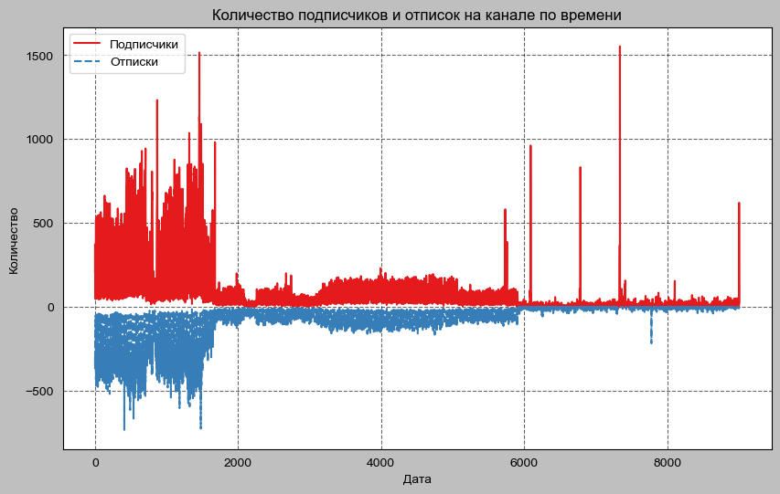

```python
# График подписчиков и отписок на канале
plt.figure(figsize=(10, 6))

# Цвета линий
colors = sns.color_palette('Set1', n_colors=2)

# Линии графика
sns.lineplot(data=subs_detailed_after_2023[['subscribers', 'unsubscribed']], palette=colors)

# Добавление сетки
plt.grid(True, linestyle='--', alpha=0.6)

# Добавление легенды
plt.legend(['Подписчики', 'Отписки'], loc='upper left')

# Заголовок и метки осей
plt.title('Количество подписчиков и отписок на канале по времени')
plt.xlabel('Дата')
plt.ylabel('Количество')

# Вывод графика
plt.show()
```

Посмотрим на изменения числа подписчиков по месяцам.

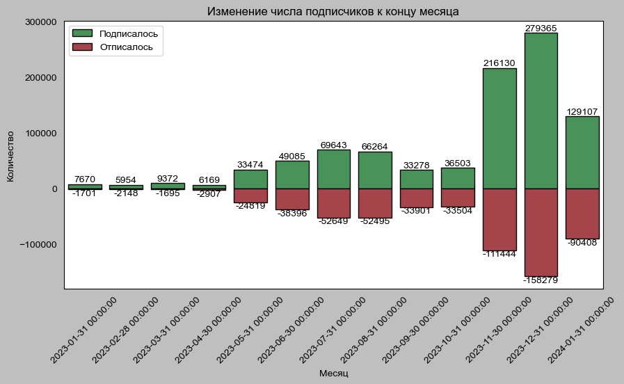

```python
x = subs_detailed[subs_detailed['date'].dt.year != 2022].copy()
x = x.set_index('date').resample('M').sum()

plt.figure(figsize=(10, 5))
sns.barplot(data=x, x=x.index, y='subscribers', color='#3CA054', label='Подписалось')
sns.barplot(data=x, x=x.index, y='unsubscribed', color='#B5353D', label='Отписалось')

#добавим подписи данных
for index, value in enumerate(x['subscribers']):
    plt.text(index, value, str(value), ha='center', va='bottom')

for index, value in enumerate(x['unsubscribed']):
    plt.text(index, value, str(value), ha='center', va='top')

plt.title('Изменение числа подписчиков к концу месяца')
plt.ylabel('Количество')
plt.xlabel('Месяц')
plt.xticks(rotation=45)
plt.legend()

plt.show()
```

С начала 2023 года только в сентябре число отписавшихся превысило число подписавшихся. В начале 2023 число отписок значительно уступало числу подписок, но уже с мая 2023 доля отписок стала увеличиваться. Для стабильного прироста числа подписчиков, каналу нужно проводить меры по удержанию действующих аудитории. Стоит отметить, что в имеющихся данных нет информации о ботах, возможно резкие колебания подписок и отписок, объясняются нашествие и удалением ботов.

# Анализ данных

# 1 Вывести метрики эффективности поста

a. Тип публикации

b. Тема

c. Объем текста

d. Отсутствие / наличие эмодзи

e. Отсутствие / наличие изображений

f. Знаки препинания (сложность текста)

```python
df.columns
```

```
Index(['id', 'date', 'text', 'reactions', 'type_attachment', 'views',
       'forwarded', 'reactions_count', 'comments', 'subscribers', 'changes'],
      dtype='object')
```

```python
import string
import emoji
import pymorphy2
# Функция для проверки наличия эмодзи в тексте
def has_emoji(text):
    return any(char in emoji.emojize(':') for char in text)
```

```python
# a. Тип публикации
df['post_type'] = df['type_attachment']

# b. Тема (вы можете использовать предложенный ранее код для создания столбца "theme")
morph = pymorphy2.MorphAnalyzer()

def extract_theme(text):
    # Пример: определение темы на основе наличия ключевых слов
    if 'премьера' in text.lower():
        return 'Премьеры'
    elif 'рецензия' in text.lower():
        return 'Рецензии'
    elif 'актер' in text.lower() or 'режиссер' in text.lower():
        return 'Актеры и режиссеры'
    else:
        return 'Другое'

# Создание столбца "theme" на основе анализа текста
df['theme'] = df['text'].apply(extract_theme)

#  наличие изображений на основе текста поста
df['has_image'] = df['text'].apply(lambda x: 1 if 'изображение' in x.lower() else 0)

# c. Объем текста
df['text_length'] = df['text'].apply(len)

# d. Отсутствие / наличие эмодзи
df['has_emoji'] = df['text'].apply(has_emoji)

# f. Знаки препинания (сложность текста)
df['punctuation_count'] = df['text'].apply(lambda x: sum(1 for char in x if char in string.punctuation))

# Вывод метрик
metrics = df[['post_type', 'theme', 'text_length', 'has_emoji', 'has_image', 'punctuation_count']]
print(metrics)
```

```
                 post_type     theme  text_length  has_emoji  has_image  \
0        MessageMediaPhoto    Другое          599       True          0
1     MessageMediaDocument    Другое          377       True          0
2      MessageMediaWebPage    Другое          579       True          0
3      MessageMediaWebPage    Другое          499       True          0
4        MessageMediaPhoto    Другое          259       True          0
...                    ...       ...          ...        ...        ...
2665   MessageMediaWebPage    Другое          357       True          0
2666     MessageMediaPhoto    Другое          431       True          0
2667     MessageMediaPhoto    Другое          308       True          0
2668     MessageMediaPhoto    Другое          320       True          0
2669   MessageMediaWebPage  Премьеры          482       True          0

      punctuation_count
0                    53
1                    32
2                    49
3                    44
4                    37
...                 ...
2665                 20
2666                 23
2667                 24
2668                 18
2669                 37

[2670 rows x 6 columns]
```

```python
# Группировка данных по темам (themes) и агрегация метрик
theme_metrics = df.groupby('theme').agg({
    'text_length': 'mean',
    'has_emoji': 'mean',
    'has_image': 'mean',
    'punctuation_count': 'mean'
}).reset_index()

# Вывод результатов
theme_metrics
```

|  | theme | text_length | has_emoji | has_image | punctuation_count |
| --- | --- | --- | --- | --- | --- |
| 0 | Актеры и режиссеры | 529.813121 | 0.934394 | 0.000000 | 39.345924 |
| 1 | Другое | 346.164502 | 0.870611 | 0.000962 | 28.849447 |
| 2 | Премьеры | 472.202532 | 0.873418 | 0.012658 | 37.227848 |
| 3 | Рецензии | 896.888889 | 1.000000 | 0.000000 | 101.444444 |

```python
metrics
```

|  | post_type | theme | text_length | has_emoji | has_image | punctuation_count |
| --- | --- | --- | --- | --- | --- | --- |
| 0 | MessageMediaPhoto | Другое | 599 | True | 0 | 53 |
| 1 | MessageMediaDocument | Другое | 377 | True | 0 | 32 |
| 2 | MessageMediaWebPage | Другое | 579 | True | 0 | 49 |
| 3 | MessageMediaWebPage | Другое | 499 | True | 0 | 44 |
| 4 | MessageMediaPhoto | Другое | 259 | True | 0 | 37 |
| ... | ... | ... | ... | ... | ... | ... |
| 2665 | MessageMediaWebPage | Другое | 357 | True | 0 | 20 |
| 2666 | MessageMediaPhoto | Другое | 431 | True | 0 | 23 |
| 2667 | MessageMediaPhoto | Другое | 308 | True | 0 | 24 |
| 2668 | MessageMediaPhoto | Другое | 320 | True | 0 | 18 |
| 2669 | MessageMediaWebPage | Премьеры | 482 | True | 0 | 37 |

2670 rows × 6 columns

метрики эффективности поста теперь включают в себя следующую информацию:

- post_type: Тип публикации (например, фото, видео, ссылка).
- theme: Тема поста.
- text_length: Объем текста в посте.
- has_emoji: Наличие эмодзи в тексте поста (True/False).
- has_image: Наличие изображений в посте (True/False).
- punctuation_count: Количество знаков препинания в тексте поста.

Давайте проанализируем результаты агрегации метрик по разным темам:

Посты на тему "Рецензии" имеют значительно более длинный текст и высокий уровень использования эмодзи, что может свидетельствовать о более подробных и информативных обзорах.

Тема "Другое" имеет более короткие тексты, но сравнительно высокий уровень использования эмодзи.

Тема "Премьеры" содержит посты средней длины, среднее количество эмодзи и небольшой процент постов с изображениями.

```python
theme_metrics_sorted_by_text_length = theme_metrics.sort_values('text_length', ascending=False)
```

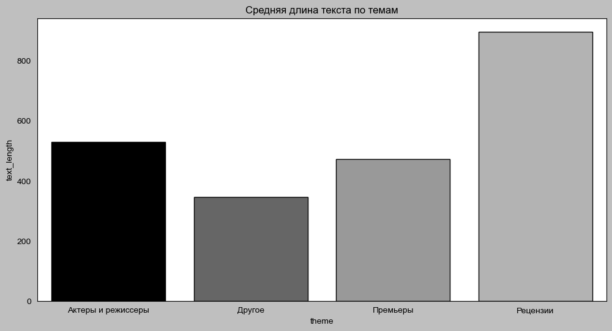

```python
# Пример графика для средней длины текста по темам
plt.figure(figsize=(12, 6))
sns.barplot(x='theme', y='text_length', data=theme_metrics)
plt.title('Средняя длина текста по темам')
plt.show()
```

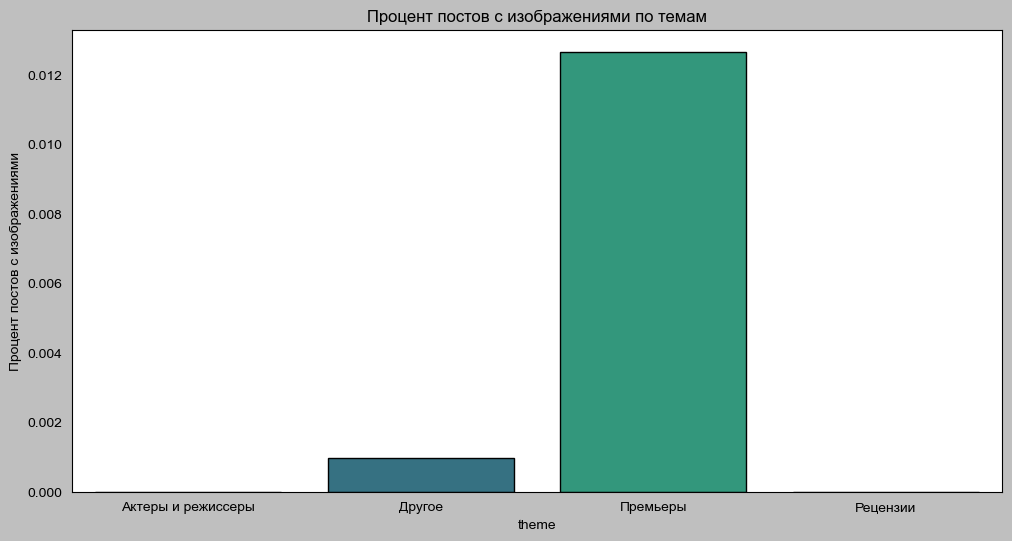

```python
# Пример графика для наличия изображений по темам
plt.figure(figsize=(12, 6))
sns.barplot(x='theme', y='has_image', data=theme_metrics, palette='viridis')
plt.title('Процент постов с изображениями по темам')
plt.ylabel('Процент постов с изображениями')
plt.show()
```

```
                                    Частотный анализ слов
```

```
                    Определим частотность слов в публикациях:
```

```python
from collections import Counter
from nltk.corpus import stopwords
```

```python
## Разбиваем текст на слова
words = df['text'].astype(str).str.split()

# Создаем корпус, фильтруя слова
corpus = [word.lower() for row in words for word in row if isinstance(word, str) and word.isalpha() and len(word) > 3]

# Создаем Series с подсчетом частоты каждого слова
word_counts = pd.Series(corpus).value_counts()

# Преобразование текста в нижний регистр и разделение на слова
words = ' '.join(df['text']).lower().split()

# Удаление стоп-слов и определенных слов (например, чтобы, если и т.д.)
stop_words = set(stopwords.words('russian'))
exclude_words = {'нашем', 'почему', 'котором', 'вместе', 'также'}
filtered_words = [word for word in words if word not in stop_words and word not in exclude_words and word.isalpha() and len(word) > 3]

# Подсчет частотности слов
word_counts = Counter(filtered_words)

# Выводим топ-30 часто встречающихся слов
top_30_words = word_counts.most_common(30)
top_30_words
```

```
[('подписывайтесь', 784),
 ('фильм', 435),
 ('который', 243),
 ('новый', 205),
 ('которые', 199),
 ('сериал', 175),
 ('фильма', 156),
 ('фильмов', 148),
 ('кино', 143),
 ('фильмы', 139),
 ('getty', 135),
 ('сегодня', 134),
 ('сериала', 132),
 ('кинопоиске', 128),
 ('читайте', 127),
 ('images', 127),
 ('главных', 119),
 ('собрали', 118),
 ('новом', 117),
 ('рассказываем', 111),
 ('роли', 110),
 ('какие', 109),
 ('главные', 106),
 ('вышел', 106),
 ('посмотреть', 104),
 ('станислав', 101),
 ('очень', 99),
 ('режиссер', 99),
 ('время', 98),
 ('выйдет', 97)]
```

```python
# Суммарное количество комментариев и реакций
df['engagement'] = df['reactions_count'] + df['comments']

# Сортировка по убыванию вовлеченности
top_engaging_posts = df.sort_values(by='engagement', ascending=False)

# Вывод топ-10 постов с наибольшей вовлеченностью
top_20_engaging_posts = top_engaging_posts.head(20)
top_20_engaging_posts
```

|  | id | date | text | reactions | type_attachment | views | forwarded | reactions_count | comments | subscribers | changes | post_type | theme | has_image | text_length | has_emoji | punctuation_count | engagement |
| --- | --- | --- | --- | --- | --- | --- | --- | --- | --- | --- | --- | --- | --- | --- | --- | --- | --- | --- |
| 1760 | 32799 | 2023-04-26 | 5 тысяч сердечек на этом посте и мы ставим Кена-Гослинга на аватарку канала 💖 | {'_': 'MessageReactions', 'results': [{'_': 'ReactionCount', 'reaction': {'_': 'ReactionEmoji', 'emoticon': '❤'}, 'count': 7484, 'chosen_order': N... | MessageMediaPhoto | 72894.0 | 383.0 | 8012 | 169 | 257581 | -186 | MessageMediaPhoto | Другое | 0 | 77 | False | 1 | 8181 |
| 1618 | 33123 | 2023-05-22 | Ушла эпоха!\n\n__Будете __[__скучать__](https://t.me/kinopoisk_Industry/1936)__ по привычному дубляжу Леонардо__ __ДиКаприо?\n__❤️__ - да__ \n👎__ ... | {'_': 'MessageReactions', 'results': [{'_': 'ReactionCount', 'reaction': {'_': 'ReactionEmoji', 'emoticon': '❤'}, 'count': 5578, 'chosen_order': N... | MessageMediaPhoto | 70984.0 | 1045.0 | 6529 | 164 | 264271 | 78 | MessageMediaPhoto | Другое | 0 | 149 | True | 39 | 6693 |
| 207 | 36607 | 2023-12-17 | Гэри Олдман благодарит судьбу за «Гарри Поттера» и «Темного рыцаря». Актер [признался,](https://www.indiewire.com/news/general-news/gary-oldman-ha... | {'_': 'MessageReactions', 'results': [{'_': 'ReactionCount', 'reaction': {'_': 'ReactionEmoji', 'emoticon': '🔥'}, 'count': 4181, 'chosen_order': N... | MessageMediaPhoto | 91394.0 | 171.0 | 6311 | 59 | 448874 | 1869 | MessageMediaPhoto | Актеры и режиссеры | 0 | 907 | True | 60 | 6370 |
| 26 | 37006 | 2024-01-13 | Роберт Дауни-младший [считает](https://variety.com/2024/film/news/robert-downey-jr-iron-man-return-offers-marvel-acting-unnoticed-1235870032/), чт... | {'_': 'MessageReactions', 'results': [{'_': 'ReactionCount', 'reaction': {'_': 'ReactionEmoji', 'emoticon': '🔥'}, 'count': 5507, 'chosen_order': N... | MessageMediaPhoto | 103564.0 | 114.0 | 6001 | 106 | 542299 | 2984 | MessageMediaPhoto | Актеры и режиссеры | 0 | 891 | True | 65 | 6107 |
| 576 | 35634 | 2023-10-29 | Умер звезда «Друзей» Мэттью Перри. Ему было 54 года.\n\nФото: Getty Images | {'_': 'MessageReactions', 'results': [{'_': 'ReactionCount', 'reaction': {'_': 'ReactionEmoji', 'emoticon': '😢'}, 'count': 3448, 'chosen_order': N... | MessageMediaPhoto | 62826.0 | 2124.0 | 5190 | 136 | 289030 | 331 | MessageMediaPhoto | Другое | 0 | 72 | True | 3 | 5326 |
| 1655 | 33042 | 2023-05-16 | Перезапуск «Назад в будущее»? \n\nТаких планов пока нет, но исполнитель роли Марти Макфлая, Майкл Дж. Фокс, уже [сформировал](https://variety.com/... | {'_': 'MessageReactions', 'results': [{'_': 'ReactionCount', 'reaction': {'_': 'ReactionEmoji', 'emoticon': '👎'}, 'count': 4757, 'chosen_order': N... | MessageMediaPhoto | 66511.0 | 80.0 | 5026 | 96 | 261954 | -105 | MessageMediaPhoto | Другое | 0 | 520 | True | 48 | 5122 |
| 1261 | 33980 | 2023-07-19 | «Барбигеймер» уже на «томатах»!\n\n__За кого болеете?\n__👍__ __—__ Нолан __— __гений\n__❤️__ __—__ «Барби» — это все__ | {'_': 'MessageReactions', 'results': [{'_': 'ReactionCount', 'reaction': {'_': 'ReactionEmoji', 'emoticon': '👍'}, 'count': 3118, 'chosen_order': N... | MessageMediaPhoto | 71598.0 | 334.0 | 4939 | 92 | 278264 | 224 | MessageMediaPhoto | Другое | 0 | 114 | False | 26 | 5031 |
| 293 | 36361 | 2023-12-04 | Тони Старк больше не появится в фильмах Marvel — это Роберту Дауни-младшему [пообещал](https://t.me/kinopoisk_soon/7469) режиссер последних «Мстит... | {'_': 'MessageReactions', 'results': [{'_': 'ReactionCount', 'reaction': {'_': 'ReactionEmoji', 'emoticon': '❤'}, 'count': 3122, 'chosen_order': N... | MessageMediaPhoto | 85502.0 | 251.0 | 4770 | 54 | 258172 | -188 | MessageMediaPhoto | Актеры и режиссеры | 0 | 335 | True | 32 | 4824 |
| 12 | 37040 | 2024-01-16 | Дженна Ортега [обещает](https://deadline.com/2024/01/jenna-ortega-teases-wednesday-season-2-1235792444/) — во втором сезоне «Уэнсдэй» будет больше... | {'_': 'MessageReactions', 'results': [{'_': 'ReactionCount', 'reaction': {'_': 'ReactionEmoji', 'emoticon': '👍'}, 'count': 3418, 'chosen_order': N... | MessageMediaPhoto | 93574.0 | 372.0 | 4545 | 37 | 548902 | 2043 | MessageMediaPhoto | Другое | 0 | 337 | True | 40 | 4582 |
| 575 | 35635 | 2023-10-29 | Прощай, любимый Чендлер 💔\n\nМы тебя не забудем. | {'_': 'MessageReactions', 'results': [{'_': 'ReactionCount', 'reaction': {'_': 'ReactionEmoji', 'emoticon': '❤'}, 'count': 2111, 'chosen_order': N... | MessageMediaDocument | 81121.0 | 899.0 | 4332 | 69 | 289030 | 331 | MessageMediaDocument | Другое | 0 | 46 | False | 2 | 4401 |
| 967 | 34691 | 2023-09-04 | Кристофер Нолан — лучший режиссер последних 25 лет по версии [Rotten Tomatoes](https://editorial.rottentomatoes.com/article/best-directors-of-the-... | {'_': 'MessageReactions', 'results': [{'_': 'ReactionCount', 'reaction': {'_': 'ReactionEmoji', 'emoticon': '👍'}, 'count': 3407, 'chosen_order': N... | MessageMediaPhoto | 49100.0 | 146.0 | 4207 | 58 | 258476 | 84 | MessageMediaPhoto | Актеры и режиссеры | 0 | 255 | True | 29 | 4265 |
| 879 | 34915 | 2023-09-17 | Нолан — гений! Теперь официально.\n\n__Рады за режиссера?\n❤️ — еще как!\n👎 — не особо \n\n__🎬 Подписывайтесь на [**«Кинопоиск»**](http://t.me/kin... | {'_': 'MessageReactions', 'results': [{'_': 'ReactionCount', 'reaction': {'_': 'ReactionEmoji', 'emoticon': '❤'}, 'count': 3645, 'chosen_order': N... | MessageMediaPhoto | 61134.0 | 378.0 | 4125 | 67 | 289817 | -148 | MessageMediaPhoto | Актеры и режиссеры | 0 | 147 | True | 21 | 4192 |
| 1971 | 32383 | 2023-03-27 | Молодому киноману на фото сегодня 60!\n\nУзнали? Сломаем кнопку лайка в честь юбилея легенды?\n\nФото: Getty Images | {'_': 'MessageReactions', 'results': [{'_': 'ReactionCount', 'reaction': {'_': 'ReactionEmoji', 'emoticon': '❤'}, 'count': 3338, 'chosen_order': N... | MessageMediaPhoto | 64051.0 | 206.0 | 4079 | 57 | 254866 | -28 | MessageMediaPhoto | Другое | 0 | 111 | True | 4 | 4136 |
| 1603 | 33160 | 2023-05-24 | «Ведьмак» после ухода Генри Кавилла — почему?\n\nШоураннер сериала Лорен Шмидт Хиссрик объяснила решение продолжать сериал после смены актера: «У ... | {'_': 'MessageReactions', 'results': [{'_': 'ReactionCount', 'reaction': {'_': 'ReactionEmoji', 'emoticon': '👎'}, 'count': 3132, 'chosen_order': N... | MessageMediaPhoto | 53903.0 | 80.0 | 3617 | 70 | 264323 | -110 | MessageMediaPhoto | Актеры и режиссеры | 0 | 439 | True | 22 | 3687 |
| 801 | 35108 | 2023-09-28 | Палочки вверх 🪄\n\n[Умер](https://www.theguardian.com/stage/2023/sep/28/michael-gambon-star-of-harry-potter-and-the-singing-detective-dies-aged-82... | {'_': 'MessageReactions', 'results': [{'_': 'ReactionCount', 'reaction': {'_': 'ReactionEmoji', 'emoticon': '😢'}, 'count': 2689, 'chosen_order': N... | MessageMediaPhoto | 103949.0 | 2739.0 | 3403 | 196 | 289270 | 83 | MessageMediaPhoto | Актеры и режиссеры | 0 | 245 | True | 29 | 3599 |
| 1440 | 33528 | 2023-06-20 | ААААААААААААА!\n\n__Ждете новый шедевр мастера?\n__❤️—__ __д__а\n__👎— н__ет__\n\n📸: Getty Images | {'_': 'MessageReactions', 'results': [{'_': 'ReactionCount', 'reaction': {'_': 'ReactionEmoji', 'emoticon': '❤'}, 'count': 2936, 'chosen_order': N... | MessageMediaPhoto | 68116.0 | 804.0 | 3448 | 40 | 266981 | 512 | MessageMediaPhoto | Другое | 0 | 90 | True | 19 | 3488 |
| 1532 | 33330 | 2023-06-05 | Капитан Джек Воробей может вернуться!\n\n__Ждете продолжение?\n__❤️__ __—__ конечно! \n__👎__ __—__ не особо__ | {'_': 'MessageReactions', 'results': [{'_': 'ReactionCount', 'reaction': {'_': 'ReactionEmoji', 'emoticon': '❤'}, 'count': 2052, 'chosen_order': N... | MessageMediaPhoto | 50443.0 | 92.0 | 3428 | 42 | 261559 | 158 | MessageMediaPhoto | Другое | 0 | 105 | False | 23 | 3470 |
| 1351 | 33762 | 2023-07-06 | Еще один сериал уходит на покой 😢\n\n__Будете скучать?\n__❤️__ __—__ да\n__👎__ __—__ нет__ | {'_': 'MessageReactions', 'results': [{'_': 'ReactionCount', 'reaction': {'_': 'ReactionEmoji', 'emoticon': '❤'}, 'count': 1741, 'chosen_order': N... | MessageMediaPhoto | 65677.0 | 413.0 | 3195 | 220 | 264084 | -30 | MessageMediaPhoto | Другое | 0 | 86 | False | 21 | 3415 |
| 443 | 35970 | 2023-11-14 | Мэтт Леблан попрощался с покойным Мэттью Перри 💔\n\nВот что актер написал в своих соцсетях:\n\n«Мэттью. С тяжелым сердцем я прощаюсь с тобой. Дни,... | {'_': 'MessageReactions', 'results': [{'_': 'ReactionCount', 'reaction': {'_': 'ReactionEmoji', 'emoticon': '❤'}, 'count': 2160, 'chosen_order': N... | MessageMediaPhoto | 78844.0 | 559.0 | 3292 | 41 | 308691 | 3345 | MessageMediaPhoto | Актеры и режиссеры | 0 | 501 | True | 18 | 3333 |
| 1471 | 33474 | 2023-06-15 | Он просто устал! \n\n__Ждете сериал по любимой вселенной?\n__🔥__ __—__ да \n__👎__ __—__ нет__ | {'_': 'MessageReactions', 'results': [{'_': 'ReactionCount', 'reaction': {'_': 'ReactionEmoji', 'emoticon': '👎'}, 'count': 2388, 'chosen_order': N... | MessageMediaPhoto | 56132.0 | 198.0 | 3270 | 62 | 263944 | -217 | MessageMediaPhoto | Другое | 0 | 89 | False | 22 | 3332 |

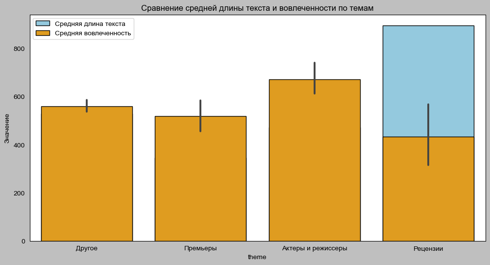

```python
# Пример графика для средней длины текста и вовлеченности по темам
plt.figure(figsize=(12, 6))
sns.barplot(x='theme', y='text_length', data=theme_metrics, color='skyblue', label='Средняя длина текста')
sns.barplot(x='theme', y='engagement', data=df, color='orange', label='Средняя вовлеченность')
plt.title('Сравнение средней длины текста и вовлеченности по темам')
plt.ylabel('Значение')
plt.legend()
plt.show()
```

# 2 Семантический анализ комментариев к постам

# какие посты побуждают людей к действию.

```
             Анализ семантического ядра предполагает исследование ключевых тем и понятий в текстовых данных для выделения смысла и выявления основных тенденций. Для проведения анализа семантического ядра вам может потребоваться использовать различные методы обработки естественного языка (Natural Language Processing, NLP)
```

```
                        Определим частотность слов в комментариях:
```

```python
from collections import Counter

def get_word_frequencies(comments):
    # Исключаемые слова
    excluded_words = {'чтобы'}

    # Разбиваем комментарии на слова, приводим к нижнему регистру и исключаем указанные слова
    words = [word.lower() for comment in comments['text_comment'] for word in comment.split() if word.lower() not in excluded_words]

    # Подсчитываем частотность слов
    word_frequencies = Counter(words)

    return word_frequencies

# Применяем функцию к датафрейму с комментариями
comments_word_frequencies = get_word_frequencies(comments)

# Выводим топ-30 часто встречающихся слов
top_30_words = comments_word_frequencies.most_common(30)
top_30_words
```

```
[('и', 38731),
 ('не', 37944),
 ('в', 33573),
 ('что', 19020),
 ('на', 18152),
 ('а', 16439),
 ('это', 14986),
 ('я', 13829),
 ('с', 12899),
 ('как', 11313),
 ('но', 10202),
 ('-', 7801),
 ('так', 7333),
 ('у', 7153),
 ('по', 6654),
 ('все', 6157),
 ('он', 6028),
 ('из', 6011),
 ('ну', 5929),
 ('фильм', 5837),
 ('то', 5630),
 ('же', 5148),
 ('бы', 5050),
 ('за', 5033),
 ('очень', 4812),
 ('если', 4715),
 ('уже', 4589),
 ('про', 4585),
 ('его', 4580),
 ('мне', 4480)]
```

Токенизация и очистка текста:

```python
# Пример создания новых столбцов для анализа
df['text_length'] = df['text'].apply(len)
df['has_emoji'] = df['text'].apply(lambda x: 1 if any(char in ['😀', '😃', '😄', '😁', '😆', '😅', '😂', '🤣'] for char in str(x)) else 0)
df['has_image'] = df['type_attachment'].apply(lambda x: 1 if 'image' in str(x) else 0)
df['punctuation_count'] = df['text'].apply(lambda x: sum(1 for char in str(x) if char in string.punctuation))

# Определение сложности текста (количество знаков препинания)
def text_complexity(text):
    punctuation_count = sum(1 for char in str(text) if char in string.punctuation)
    if punctuation_count == 0:
        return 'Низкая'
    elif punctuation_count <= 3:
        return 'Средняя'
    else:
        return 'Высокая'

df['text_complexity'] = df['text'].apply(text_complexity)
```

Векторизация текста:

```python
from sklearn.feature_extraction.text import TfidfVectorizer

# Пример векторизации текста с использованием TF-IDF
tfidf_vectorizer = TfidfVectorizer(max_features=1000)
tfidf_matrix = tfidf_vectorizer.fit_transform(df['text'])
```

Кластеризация:

```python
from sklearn.cluster import KMeans

# Пример кластеризации текста с использованием K-Means
kmeans = KMeans(n_clusters=5)
df['cluster'] = kmeans.fit_predict(tfidf_matrix)
```

Извлечение ключевых слов:

```python
from sklearn.feature_extraction.text import CountVectorizer

# Пример извлечения ключевых слов
count_vectorizer = CountVectorizer(max_features=100)
count_matrix = count_vectorizer.fit_transform(df['text'])
keywords = count_vectorizer.get_feature_names_out()
```

Визуализация результатов:

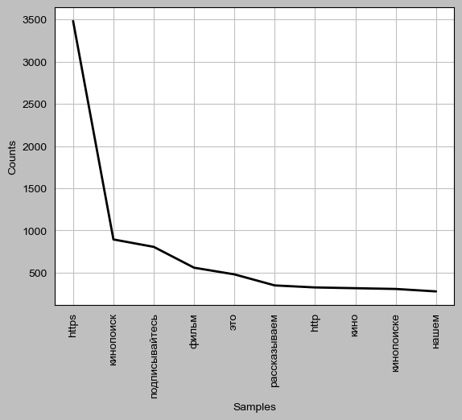

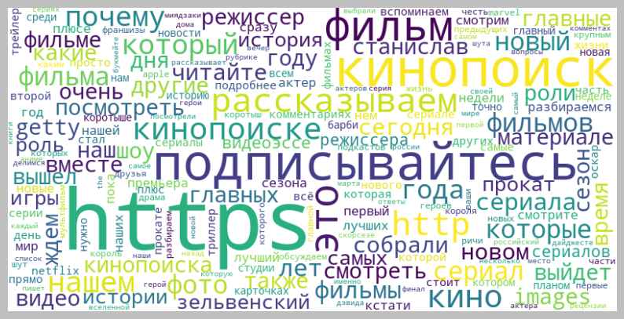

```python
# Предварительная обработка текста
stop_words = set(stopwords.words('russian'))

def preprocess_text(text):
    tokens = word_tokenize(text.lower())
    tokens = [word for word in tokens if word.isalpha() and word not in stop_words]
    return tokens

df['processed_text'] = df['text'].apply(preprocess_text)

# Анализ частоты слов
all_words = [word for tokens in df['processed_text'] for word in tokens]
freq_dist = FreqDist(all_words)

# Визуализация частоты слов (10 самых частых слов)
freq_dist.plot(10, cumulative=False)
plt.show()

# Word Cloud (Облако слов)
wordcloud = WordCloud(width=800, height=400, random_state=21, max_font_size=110, background_color='white').generate_from_frequencies(freq_dist)
plt.figure(figsize=(10, 8))
plt.imshow(wordcloud, interpolation="bilinear")
plt.axis('off')
plt.show()
```

# 3 Анализ эмодзи / реакций

```
                      Самое большое колличество реакций
```

```python
df['reactions_count'].value_counts(dropna=False)
```

```
237     13
222     13
213     12
215     12
233     12
        ..
1100     1
1757     1
1730     1
2491     1
811      1
Name: reactions_count, Length: 983, dtype: int64
```

```python
df['reactions_count'].max()
```

```
8012
```

```
                              Анализ эмодзи к постам
```

```python
df_emoji = df.copy()
```

```python
pip install emot
```

```python
df_emoji.columns
```

```
Index(['id', 'date', 'text', 'reactions', 'type_attachment', 'views',
       'forwarded', 'reactions_count', 'comments', 'subscribers', 'changes',
       'post_type', 'theme', 'has_image', 'text_length', 'has_emoji',
       'punctuation_count', 'engagement', 'text_complexity', 'cluster',
       'processed_text'],
      dtype='object')
```

```python
import regex

def extract_emojis(text):
    emoji_pattern = regex.compile("["
                           u"\U0001F600-\U0001F64F"  # emoticons
                           u"\U0001F300-\U0001F5FF"  # symbols & pictographs
                           u"\U0001F680-\U0001F6FF"  # transport & map symbols
                           u"\U0001F700-\U0001F77F"  # alchemical symbols
                           u"\U0001F780-\U0001F7FF"  # Geometric Shapes Extended
                           u"\U0001F800-\U0001F8FF"  # Supplemental Arrows-C
                           u"\U0001F900-\U0001F9FF"  # Supplemental Symbols and Pictographs
                           u"\U0001FA00-\U0001FA6F"  # Chess Symbols
                           u"\U0001FA70-\U0001FAFF"  # Symbols and Pictographs Extended-A
                           u"\U00002702-\U000027B0"  # Dingbats
                           u"\U000024C2-\U0001F251"
                           "]+", flags=regex.UNICODE)
    return ''.join(emoji_pattern.findall(text))

# Применение функции для извлечения эмодзи из каждого текста поста
df_emoji['extracted_emojis'] = df_emoji['text'].apply(extract_emojis)

# Создание столбца с количеством уникальных эмодзи в каждом посте
df_emoji['unique_emoji_count'] = df_emoji['extracted_emojis'].apply(lambda x: len(set(x)))

# Вывод столбца с извлеченными эмодзи и количеством уникальных эмодзи
print(df_emoji[['text', 'extracted_emojis', 'unique_emoji_count']])
```

```
                                                                                                                                                       text  \
0     Сериал недели — [**«Как друзья Захара женили»**](https://www.kinopoisk.ru/series/4895610/)[ ](https://www.kinopoisk.ru/series/4895610/)💍\n\nПрямо ...
1     «Суперсилы — это скучно, у всех есть суперсилы. А суперслабости нет ни у кого».\n\nТак считает Сироткин — наш новый гость в шоу «Дежурный по Киноп...
2     Клайв Оуэн снова на коне и готов покорять ваши сердечки 🔥\n\nСтанислав Зельвенский [пишет](https://www.kinopoisk.ru/media/article/4008972/?utm_sou...
3     Да начнется [наше видеоэссе](https://www.youtube.com/watch?v=qGSx8ZsGYGI) про «Голодные игры» 🏹\n\nХотя «Голодные игры» и не тянут на главную анти...
4     А вот и персонажные постеры [«Иных»](https://www.kinopoisk.ru/series/5368058/)! \n\nЛюбуемся на главных героев, ждем премьеру сериала 25 января на...
...                                                                                                                                                     ...
2665  Некоторые франшизы созданы для того, чтобы пересматривать их в новогодние праздники, и фильмы о Мальчике-который-выжил уже давно ассоциируются у м...
2666  «Гром: Трудное детство» выходит на Кинопоиске вечером — а вот послушать саундтрек можно уже сейчас. \n\nПлейлист с композициями из фильма уже [дос...
2667  Новый год, новый месяц, новые сериалы.\n\nВыбрали для вас 9 главных новинок января — от неонуара Николаса Виндинга Рефна до экранизации «The Last ...
2668  Новый год — новые киновпечатления!🎄🎬\n\nУже сегодня на K1 можно будет посмотреть долгожданный приквел «Майора Грома» — «Трудное детство».\n\n[Вклю...
2669  Вышел первый [трейлер](https://youtu.be/PKBKmaOFlsg) фильма «Вызов» Клима Шипенко — того самого, ради которого режиссер вместе с актрисой Юлией Пе...

     extracted_emojis  unique_emoji_count
0                  💍🔥                   2
1                   🔥                   1
2                  🔥🔥                   1
3                  🏹🔥                   2
4                  ⚡️                   2
...               ...                 ...
2665                                    0
2666                                    0
2667                                    0
2668               🎄🎬                   2
2669                                    0

[2670 rows x 3 columns]
```

```python
df_emoji
```

|  | id | date | text | reactions | type_attachment | views | forwarded | reactions_count | comments | subscribers | ... | has_image | text_length | has_emoji | punctuation_count | engagement | text_complexity | cluster | processed_text | extracted_emojis | unique_emoji_count |
| --- | --- | --- | --- | --- | --- | --- | --- | --- | --- | --- | --- | --- | --- | --- | --- | --- | --- | --- | --- | --- | --- |
| 0 | 37060 | 2024-01-17 | Сериал недели — [**«Как друзья Захара женили»**](https://www.kinopoisk.ru/series/4895610/)[ ](https://www.kinopoisk.ru/series/4895610/)💍\n\nПрямо ... | {'_': 'MessageReactions', 'results': [{'_': 'ReactionCount', 'reaction': {'_': 'ReactionEmoji', 'emoticon': '👎'}, 'count': 239, 'chosen_order': No... | MessageMediaPhoto | 89165.0 | 203.0 | 519 | 30 | 550963 | ... | 0 | 599 | 0 | 53 | 549 | Высокая | 3 | [сериал, недели, друзья, захара, женили, https, https, прямо, накануне, свадьбы, захара, сергей, бондарчук, бросает, невеста, помощью, друзей, кот... | 💍🔥 | 2 |
| 1 | 37059 | 2024-01-17 | «Суперсилы — это скучно, у всех есть суперсилы. А суперслабости нет ни у кого».\n\nТак считает Сироткин — наш новый гость в шоу «Дежурный по Киноп... | {'_': 'MessageReactions', 'results': [{'_': 'ReactionCount', 'reaction': {'_': 'ReactionEmoji', 'emoticon': '❤'}, 'count': 238, 'chosen_order': No... | MessageMediaDocument | 85666.0 | 111.0 | 376 | 12 | 550963 | ... | 0 | 377 | 0 | 32 | 388 | Высокая | 3 | [суперсилы, это, скучно, суперсилы, суперслабости, кого, считает, сироткин, наш, новый, гость, шоу, дежурный, кинопоиску, серёжа, группа, побывали... | 🔥 | 1 |
| 2 | 37058 | 2024-01-17 | Клайв Оуэн снова на коне и готов покорять ваши сердечки 🔥\n\nСтанислав Зельвенский [пишет](https://www.kinopoisk.ru/media/article/4008972/?utm_sou... | {'_': 'MessageReactions', 'results': [{'_': 'ReactionCount', 'reaction': {'_': 'ReactionEmoji', 'emoticon': '🔥'}, 'count': 144, 'chosen_order': No... | MessageMediaWebPage | 87095.0 | 193.0 | 232 | 18 | 550963 | ... | 0 | 579 | 0 | 49 | 250 | Высокая | 2 | [клайв, оуэн, снова, коне, готов, покорять, ваши, сердечки, станислав, зельвенский, пишет, https, сериале, месье, спейд, детективном, триллере, сы... | 🔥🔥 | 1 |
| 3 | 37057 | 2024-01-17 | Да начнется [наше видеоэссе](https://www.youtube.com/watch?v=qGSx8ZsGYGI) про «Голодные игры» 🏹\n\nХотя «Голодные игры» и не тянут на главную анти... | {'_': 'MessageReactions', 'results': [{'_': 'ReactionCount', 'reaction': {'_': 'ReactionEmoji', 'emoticon': '❤'}, 'count': 482, 'chosen_order': No... | MessageMediaWebPage | 86816.0 | 436.0 | 729 | 41 | 550963 | ... | 0 | 499 | 0 | 44 | 770 | Высокая | 3 | [начнется, наше, видеоэссе, https, голодные, игры, хотя, голодные, игры, тянут, главную, антиутопию, времен, серия, остается, уникальным, примером... | 🏹🔥 | 2 |
| 4 | 37053 | 2024-01-17 | А вот и персонажные постеры [«Иных»](https://www.kinopoisk.ru/series/5368058/)! \n\nЛюбуемся на главных героев, ждем премьеру сериала 25 января на... | {'_': 'MessageReactions', 'results': [{'_': 'ReactionCount', 'reaction': {'_': 'ReactionEmoji', 'emoticon': '❤'}, 'count': 270, 'chosen_order': No... | MessageMediaPhoto | 74821.0 | 154.0 | 471 | 38 | 550963 | ... | 0 | 259 | 0 | 37 | 509 | Высокая | 3 | [персонажные, постеры, иных, https, любуемся, главных, героев, ждем, премьеру, сериала, января, кинопоиске, ломаем, кнопку, лайка, подписывайтесь,... | ⚡️ | 2 |
| ... | ... | ... | ... | ... | ... | ... | ... | ... | ... | ... | ... | ... | ... | ... | ... | ... | ... | ... | ... | ... | ... |
| 2665 | 31149 | 2023-01-01 | Некоторые франшизы созданы для того, чтобы пересматривать их в новогодние праздники, и фильмы о Мальчике-который-выжил уже давно ассоциируются у м... | {'_': 'MessageReactions', 'results': [{'_': 'ReactionCount', 'reaction': {'_': 'ReactionEmoji', 'emoticon': '👍'}, 'count': 273, 'chosen_order': No... | MessageMediaWebPage | 53728.0 | 101.0 | 435 | 129 | 226447 | ... | 0 | 357 | 0 | 20 | 564 | Высокая | 0 | [некоторые, франшизы, созданы, пересматривать, новогодние, праздники, фильмы, давно, ассоциируются, многих, именно, этим, временем, года, решили, ... |  | 0 |
| 2666 | 31147 | 2023-01-01 | «Гром: Трудное детство» выходит на Кинопоиске вечером — а вот послушать саундтрек можно уже сейчас. \n\nПлейлист с композициями из фильма уже [дос... | {'_': 'MessageReactions', 'results': [{'_': 'ReactionCount', 'reaction': {'_': 'ReactionEmoji', 'emoticon': '🔥'}, 'count': 331, 'chosen_order': No... | MessageMediaPhoto | 53993.0 | 126.0 | 535 | 36 | 226447 | ... | 0 | 431 | 0 | 23 | 571 | Высокая | 0 | [гром, трудное, детство, выходит, кинопоиске, вечером, послушать, саундтрек, плейлист, композициями, фильма, доступен, https, яндекс, музыке, внут... |  | 0 |
| 2667 | 31137 | 2023-01-01 | Новый год, новый месяц, новые сериалы.\n\nВыбрали для вас 9 главных новинок января — от неонуара Николаса Виндинга Рефна до экранизации «The Last ... | {'_': 'MessageReactions', 'results': [{'_': 'ReactionCount', 'reaction': {'_': 'ReactionEmoji', 'emoticon': '❤'}, 'count': 214, 'chosen_order': No... | MessageMediaPhoto | 49091.0 | 329.0 | 335 | 15 | 226447 | ... | 0 | 308 | 0 | 24 | 350 | Высокая | 2 | [новый, год, новый, месяц, новые, сериалы, выбрали, главных, новинок, января, неонуара, николаса, виндинга, рефна, экранизации, the, last, of, us,... |  | 0 |
| 2668 | 31136 | 2023-01-01 | Новый год — новые киновпечатления!🎄🎬\n\nУже сегодня на K1 можно будет посмотреть долгожданный приквел «Майора Грома» — «Трудное детство».\n\n[Вклю... | {'_': 'MessageReactions', 'results': [{'_': 'ReactionCount', 'reaction': {'_': 'ReactionEmoji', 'emoticon': '👍'}, 'count': 289, 'chosen_order': No... | MessageMediaPhoto | 51746.0 | 92.0 | 411 | 40 | 226447 | ... | 0 | 320 | 0 | 18 | 451 | Высокая | 0 | [новый, год, новые, киновпечатления, сегодня, посмотреть, долгожданный, приквел, майора, грома, трудное, детство, включайте, поток, https, смотрит... | 🎄🎬 | 2 |
| 2669 | 31135 | 2023-01-01 | Вышел первый [трейлер](https://youtu.be/PKBKmaOFlsg) фильма «Вызов» Клима Шипенко — того самого, ради которого режиссер вместе с актрисой Юлией Пе... | {'_': 'MessageReactions', 'results': [{'_': 'ReactionCount', 'reaction': {'_': 'ReactionEmoji', 'emoticon': '👎'}, 'count': 163, 'chosen_order': No... | MessageMediaWebPage | 49611.0 | 101.0 | 340 | 19 | 226447 | ... | 0 | 482 | 0 | 37 | 359 | Высокая | 2 | [вышел, первый, трейлер, https, фильма, вызов, клима, шипенко, самого, ради, которого, режиссер, вместе, актрисой, юлией, пересильд, поднимался, б... |  | 0 |

2670 rows × 23 columns

```python
total_unique_emoji_count = df_emoji['unique_emoji_count'].sum()
print("Общее количество уникальных эмодзи в постах:", total_unique_emoji_count)
```

```
Общее количество уникальных эмодзи в постах: 2527
```

```python
emoji_count_stats = df_emoji['unique_emoji_count'].describe()
print("Статистика по количеству уникальных эмодзи в постах:\n", emoji_count_stats)
```

```
Статистика по количеству уникальных эмодзи в постах:
 count    2670.000000
mean        0.946442
std         1.127560
min         0.000000
25%         0.000000
50%         1.000000
75%         1.000000
max         9.000000
Name: unique_emoji_count, dtype: float64
```

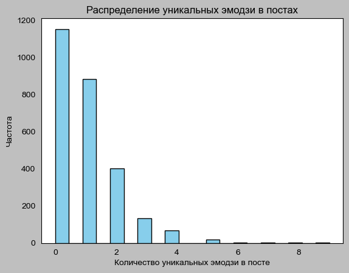

```python
plt.hist(df_emoji['unique_emoji_count'], bins=20, color='skyblue', edgecolor='black')
plt.title('Распределение уникальных эмодзи в постах')
plt.xlabel('Количество уникальных эмодзи в посте')
plt.ylabel('Частота')
plt.show()
```

```python
from collections import Counter
import emoji

# Создание списка всех эмодзи в постах
all_emojis = ''.join(df_emoji['extracted_emojis'])

# Подсчет количества каждого эмодзи
emoji_counter = Counter(all_emojis)

# Вывод топ N популярных эмодзи
top_n = 10  # Замените на желаемое количество топ-эмодзи
top_emojis = emoji_counter.most_common(top_n)

# Вывод результатов
print(f"Топ-{top_n} популярных эмодзи:")
for emoji, count in top_emojis:
    print(f"{emoji} - {count} раз")
```

```
Топ-10 популярных эмодзи:
🔥 - 687 раз
️ - 393 раз
🎬 - 230 раз
❤ - 140 раз
⚡ - 96 раз
▫ - 93 раз
📺 - 74 раз
👀 - 70 раз
👎 - 60 раз
📸 - 50 раз
```

```python
import regex
from collections import Counter

# Создание списка всех эмодзи в постах
all_emojis = ''.join(df_emoji['extracted_emojis'])

# Используем regex для извлечения всех эмодзи
emoji_list = regex.findall(r'\X', all_emojis)

# Подсчет количества каждого эмодзи
emoji_counter = Counter(emoji_list)

# Вывод топ N популярных эмодзи
top_n = 10  # Замените на желаемое количество топ-эмодзи
top_emojis = emoji_counter.most_common(top_n)

# Вывод результатов
print(f"Топ-{top_n} популярных эмодзи:")
for emoji, count in top_emojis:
    print(f"{emoji} - {count} раз")
```

```
Топ-10 популярных эмодзи:
🔥 - 687 раз
🎬 - 230 раз
❤️ - 139 раз
▫️ - 91 раз
📺 - 74 раз
⚡️ - 73 раз
👀 - 70 раз
👎 - 56 раз
📸 - 50 раз
📚 - 37 раз
```

# 4 Посчитать метрики эффективности каждого поста

a. Охват публикаций

b. Вовлеченность аудитории

```
                         Анализ влияния объема текста публикации
```

```python
comments
```

|  | post_id | date_comment | text_comment |
| --- | --- | --- | --- |
| 0 | 37068 | 2024-01-18 12:34:31+03:00 | От бесстыжих к медведю - так это скорее не путь, а спуск |
| 1 | 37068 | 2024-01-18 12:35:00+03:00 | учился орать FUCK! |
| 2 | 37068 | 2024-01-18 12:35:11+03:00 | Верните бестыжих |
| 3 | 37068 | 2024-01-18 12:36:34+03:00 | От липа из бесстыжих до рекламы кельвин кляйн |
| 4 | 37068 | 2024-01-18 12:37:41+03:00 | этот навык был освоен еще в "бесстыжих"🧡 |
| ... | ... | ... | ... |
| 132187 | 28701 | 2022-09-22 16:45:08+03:00 | Кто-нибудь может мне объяснить, зачем нужно смотреть кадры к будущему сериалу?? |
| 132188 | 28701 | 2022-09-22 18:24:09+03:00 | Киньте ноомального бота фильмов |
| 132189 | 28701 | 2022-09-24 21:15:35+03:00 | Жду. |
| 132190 | 28701 | 2022-09-28 17:36:49+03:00 | Я этот сериал смотрю только из-за костюмов. Как когда-то «Секс в БГ». Такое наслаждение для глаз. И пусть он наивный, туповатый и слишком девочков... |
| 132191 | 28701 | 2022-10-01 11:11:06+03:00 | Полностью поддерживаю последний комент, а ещё слежу за романтической линией между главной героиней и поваренка🌸 👨‍🍳 |

132192 rows × 3 columns

```python
comments.info()
```

```
<class 'pandas.core.frame.DataFrame'>
RangeIndex: 132192 entries, 0 to 132191
Data columns (total 3 columns):
 #   Column        Non-Null Count   Dtype
---  ------        --------------   -----
 0   post_id       132192 non-null  int64
 1   date_comment  132192 non-null  datetime64[ns, Europe/Moscow]
 2   text_comment  132192 non-null  object
dtypes: datetime64[ns, Europe/Moscow](1), int64(1), object(1)
memory usage: 3.0+ MB
```

```python
comments['text_volume'] = comments['text_comment'].str.len()
```

```python
comments['text_volume'] = comments['text_volume'].fillna(0)
```

```python
comments['text_volume'] = comments['text_volume'].astype('int')
```

```python
comments['text_comment'].value_counts(dropna=False).head(20)
```

```
Да              234
3               161
Привет          152
Спасибо         142
Нет             137
👍               129
+               105
Оппенгеймер      91
1                81
?                75
Кино             68
Интерстеллар     65
Ага              57
да               54
Согласен         53
Тор              52
❤️               52
.                47
Salom            46
Начало           43
Name: text_comment, dtype: int64
```

Определили разброс объемов текста . Создадим столбец с категориями длины текста:

```python
def categorize_volume(volume):
    try:
        if 0 <= volume <= 10:
            return 'очень короткий текст (0-10)'
        elif 11 <= volume <= 20:
            return 'короткий текст(11-20)'
        elif 21 <= volume <= 30:
            return 'средний текст (21-30)'
        elif 31 <= volume <= 50:
            return 'длинный текст(31-50)'
        elif 51<= volume <= 100:
            return 'очень длинный текст(51-100)'
        elif 101<= volume <= 2000:
            return 'больше 101'
    except:
        pass
```

```python
comments['text_volume_cat'] = comments['text_volume'].apply(categorize_volume)
```

```python
comments['text_volume_cat'].value_counts(dropna=False)
```

```
очень длинный текст(51-100)    28815
длинный текст(31-50)           25031
больше 101                     22187
короткий текст(11-20)          21905
средний текст (21-30)          17465
очень короткий текст (0-10)    16768
None                              21
Name: text_volume_cat, dtype: int64
```

в процентах

```python
comments_gr_share = comments.groupby('text_volume_cat')['post_id'].count()/comments['post_id'].count()*100
comments_gr_share
```

```
text_volume_cat
больше 101                     16.783920
длинный текст(31-50)           18.935336
короткий текст(11-20)          16.570594
очень длинный текст(51-100)    21.797840
очень короткий текст (0-10)    12.684580
средний текст (21-30)          13.211843
Name: post_id, dtype: float64
```

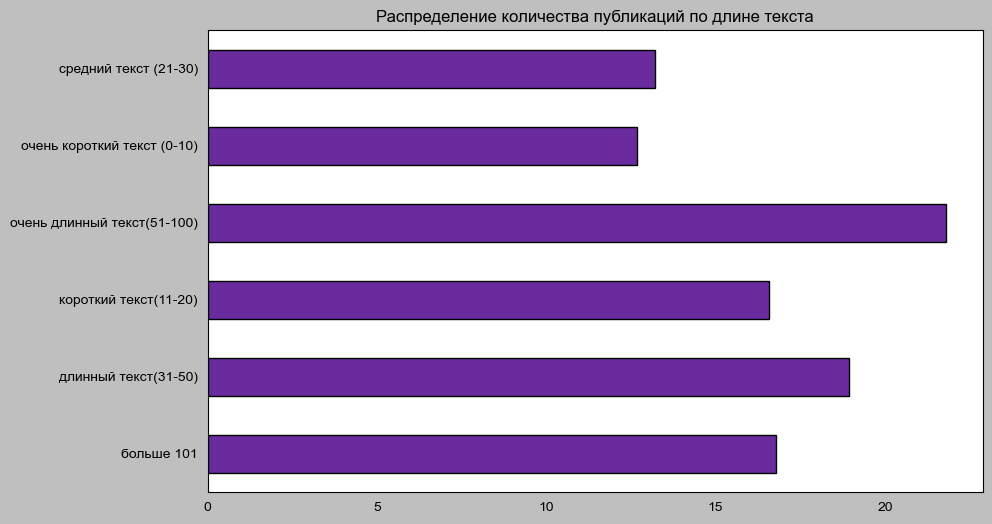

```python
comments_gr_share.plot(kind='barh', title='Распределение количества публикаций по длине текста',
 ylabel='% от общего количества публикаций', xlabel='', color='#692B9E', figsize=( 10 , 6 ))
```

```python
# Охват публикаций
reach = df['subscribers'] + df['views'] + df['forwarded']

# Вовлеченность аудитории
engagement = df['reactions_count'] + df['comments'] + df['forwarded']

# Добавление новых столбцов в DataFrame
df['reach'] = reach
df['engagement'] = engagement
```

```python
df.columns
```

```
Index(['id', 'date', 'text', 'reactions', 'type_attachment', 'views',
       'forwarded', 'reactions_count', 'comments', 'subscribers', 'changes',
       'post_type', 'theme', 'has_image', 'text_length', 'has_emoji',
       'punctuation_count', 'engagement', 'text_complexity', 'cluster',
       'processed_text', 'reach'],
      dtype='object')
```

```python
df
```

|  | id | date | text | reactions | type_attachment | views | forwarded | reactions_count | comments | subscribers | ... | theme | has_image | text_length | has_emoji | punctuation_count | engagement | text_complexity | cluster | processed_text | reach |
| --- | --- | --- | --- | --- | --- | --- | --- | --- | --- | --- | --- | --- | --- | --- | --- | --- | --- | --- | --- | --- | --- |
| 0 | 37060 | 2024-01-17 | Сериал недели — [**«Как друзья Захара женили»**](https://www.kinopoisk.ru/series/4895610/)[ ](https://www.kinopoisk.ru/series/4895610/)💍\n\nПрямо ... | {'_': 'MessageReactions', 'results': [{'_': 'ReactionCount', 'reaction': {'_': 'ReactionEmoji', 'emoticon': '👎'}, 'count': 239, 'chosen_order': No... | MessageMediaPhoto | 89165.0 | 203.0 | 519 | 30 | 550963 | ... | Другое | 0 | 599 | 0 | 53 | 752.0 | Высокая | 3 | [сериал, недели, друзья, захара, женили, https, https, прямо, накануне, свадьбы, захара, сергей, бондарчук, бросает, невеста, помощью, друзей, кот... | 640331.0 |
| 1 | 37059 | 2024-01-17 | «Суперсилы — это скучно, у всех есть суперсилы. А суперслабости нет ни у кого».\n\nТак считает Сироткин — наш новый гость в шоу «Дежурный по Киноп... | {'_': 'MessageReactions', 'results': [{'_': 'ReactionCount', 'reaction': {'_': 'ReactionEmoji', 'emoticon': '❤'}, 'count': 238, 'chosen_order': No... | MessageMediaDocument | 85666.0 | 111.0 | 376 | 12 | 550963 | ... | Другое | 0 | 377 | 0 | 32 | 499.0 | Высокая | 3 | [суперсилы, это, скучно, суперсилы, суперслабости, кого, считает, сироткин, наш, новый, гость, шоу, дежурный, кинопоиску, серёжа, группа, побывали... | 636740.0 |
| 2 | 37058 | 2024-01-17 | Клайв Оуэн снова на коне и готов покорять ваши сердечки 🔥\n\nСтанислав Зельвенский [пишет](https://www.kinopoisk.ru/media/article/4008972/?utm_sou... | {'_': 'MessageReactions', 'results': [{'_': 'ReactionCount', 'reaction': {'_': 'ReactionEmoji', 'emoticon': '🔥'}, 'count': 144, 'chosen_order': No... | MessageMediaWebPage | 87095.0 | 193.0 | 232 | 18 | 550963 | ... | Другое | 0 | 579 | 0 | 49 | 443.0 | Высокая | 2 | [клайв, оуэн, снова, коне, готов, покорять, ваши, сердечки, станислав, зельвенский, пишет, https, сериале, месье, спейд, детективном, триллере, сы... | 638251.0 |
| 3 | 37057 | 2024-01-17 | Да начнется [наше видеоэссе](https://www.youtube.com/watch?v=qGSx8ZsGYGI) про «Голодные игры» 🏹\n\nХотя «Голодные игры» и не тянут на главную анти... | {'_': 'MessageReactions', 'results': [{'_': 'ReactionCount', 'reaction': {'_': 'ReactionEmoji', 'emoticon': '❤'}, 'count': 482, 'chosen_order': No... | MessageMediaWebPage | 86816.0 | 436.0 | 729 | 41 | 550963 | ... | Другое | 0 | 499 | 0 | 44 | 1206.0 | Высокая | 3 | [начнется, наше, видеоэссе, https, голодные, игры, хотя, голодные, игры, тянут, главную, антиутопию, времен, серия, остается, уникальным, примером... | 638215.0 |
| 4 | 37053 | 2024-01-17 | А вот и персонажные постеры [«Иных»](https://www.kinopoisk.ru/series/5368058/)! \n\nЛюбуемся на главных героев, ждем премьеру сериала 25 января на... | {'_': 'MessageReactions', 'results': [{'_': 'ReactionCount', 'reaction': {'_': 'ReactionEmoji', 'emoticon': '❤'}, 'count': 270, 'chosen_order': No... | MessageMediaPhoto | 74821.0 | 154.0 | 471 | 38 | 550963 | ... | Другое | 0 | 259 | 0 | 37 | 663.0 | Высокая | 3 | [персонажные, постеры, иных, https, любуемся, главных, героев, ждем, премьеру, сериала, января, кинопоиске, ломаем, кнопку, лайка, подписывайтесь,... | 625938.0 |
| ... | ... | ... | ... | ... | ... | ... | ... | ... | ... | ... | ... | ... | ... | ... | ... | ... | ... | ... | ... | ... | ... |
| 2665 | 31149 | 2023-01-01 | Некоторые франшизы созданы для того, чтобы пересматривать их в новогодние праздники, и фильмы о Мальчике-который-выжил уже давно ассоциируются у м... | {'_': 'MessageReactions', 'results': [{'_': 'ReactionCount', 'reaction': {'_': 'ReactionEmoji', 'emoticon': '👍'}, 'count': 273, 'chosen_order': No... | MessageMediaWebPage | 53728.0 | 101.0 | 435 | 129 | 226447 | ... | Другое | 0 | 357 | 0 | 20 | 665.0 | Высокая | 0 | [некоторые, франшизы, созданы, пересматривать, новогодние, праздники, фильмы, давно, ассоциируются, многих, именно, этим, временем, года, решили, ... | 280276.0 |
| 2666 | 31147 | 2023-01-01 | «Гром: Трудное детство» выходит на Кинопоиске вечером — а вот послушать саундтрек можно уже сейчас. \n\nПлейлист с композициями из фильма уже [дос... | {'_': 'MessageReactions', 'results': [{'_': 'ReactionCount', 'reaction': {'_': 'ReactionEmoji', 'emoticon': '🔥'}, 'count': 331, 'chosen_order': No... | MessageMediaPhoto | 53993.0 | 126.0 | 535 | 36 | 226447 | ... | Другое | 0 | 431 | 0 | 23 | 697.0 | Высокая | 0 | [гром, трудное, детство, выходит, кинопоиске, вечером, послушать, саундтрек, плейлист, композициями, фильма, доступен, https, яндекс, музыке, внут... | 280566.0 |
| 2667 | 31137 | 2023-01-01 | Новый год, новый месяц, новые сериалы.\n\nВыбрали для вас 9 главных новинок января — от неонуара Николаса Виндинга Рефна до экранизации «The Last ... | {'_': 'MessageReactions', 'results': [{'_': 'ReactionCount', 'reaction': {'_': 'ReactionEmoji', 'emoticon': '❤'}, 'count': 214, 'chosen_order': No... | MessageMediaPhoto | 49091.0 | 329.0 | 335 | 15 | 226447 | ... | Другое | 0 | 308 | 0 | 24 | 679.0 | Высокая | 2 | [новый, год, новый, месяц, новые, сериалы, выбрали, главных, новинок, января, неонуара, николаса, виндинга, рефна, экранизации, the, last, of, us,... | 275867.0 |
| 2668 | 31136 | 2023-01-01 | Новый год — новые киновпечатления!🎄🎬\n\nУже сегодня на K1 можно будет посмотреть долгожданный приквел «Майора Грома» — «Трудное детство».\n\n[Вклю... | {'_': 'MessageReactions', 'results': [{'_': 'ReactionCount', 'reaction': {'_': 'ReactionEmoji', 'emoticon': '👍'}, 'count': 289, 'chosen_order': No... | MessageMediaPhoto | 51746.0 | 92.0 | 411 | 40 | 226447 | ... | Другое | 0 | 320 | 0 | 18 | 543.0 | Высокая | 0 | [новый, год, новые, киновпечатления, сегодня, посмотреть, долгожданный, приквел, майора, грома, трудное, детство, включайте, поток, https, смотрит... | 278285.0 |
| 2669 | 31135 | 2023-01-01 | Вышел первый [трейлер](https://youtu.be/PKBKmaOFlsg) фильма «Вызов» Клима Шипенко — того самого, ради которого режиссер вместе с актрисой Юлией Пе... | {'_': 'MessageReactions', 'results': [{'_': 'ReactionCount', 'reaction': {'_': 'ReactionEmoji', 'emoticon': '👎'}, 'count': 163, 'chosen_order': No... | MessageMediaWebPage | 49611.0 | 101.0 | 340 | 19 | 226447 | ... | Премьеры | 0 | 482 | 0 | 37 | 460.0 | Высокая | 2 | [вышел, первый, трейлер, https, фильма, вызов, клима, шипенко, самого, ради, которого, режиссер, вместе, актрисой, юлией, пересильд, поднимался, б... | 276159.0 |

2670 rows × 22 columns

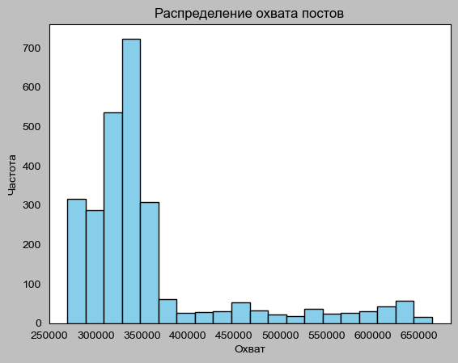

```python
# Построение гистограммы охвата
plt.hist(df['reach'], bins=20, color='skyblue', edgecolor='black')
plt.xlabel('Охват')
plt.ylabel('Частота')
plt.title('Распределение охвата постов')
plt.show()
```

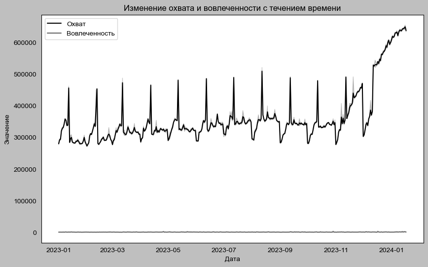

```python
# Построение линейного графика для охвата и вовлеченности
plt.figure(figsize=(10, 6))
sns.lineplot(x='date', y='reach', data=df, label='Охват')
sns.lineplot(x='date', y='engagement', data=df, label='Вовлеченность')
plt.xlabel('Дата')
plt.ylabel('Значение')
plt.title('Изменение охвата и вовлеченности с течением времени')
plt.legend()
plt.show()
```